# Tugas Pertemuan 07

#Uji ADF

```r
tseries::adf.test(datatrain.ts)
```

```
##
##  Augmented Dickey-Fuller Test
##
## data:  datatrain.ts
## Dickey-Fuller = -2.9992, Lag order = 6, p-value = 0.1551
## alternative hypothesis: stationary
```

$H_0$ : Data tidak stasioner dalam rataan

$H_1$ : Data stasioner dalam rataan

Berdasarkan uji ADF tersebut, didapat *p-value* sebesar 0.15 yang lebih besar dari taraf nyata 5% sehingga tak tolak $H_0$ dan menandakan bahwa data tidak stasioner dalam rataan. Hal ini sesuai dengan hasil eksplorasi menggunakan plot time series dan plot ACF.

#Plot Boxcox

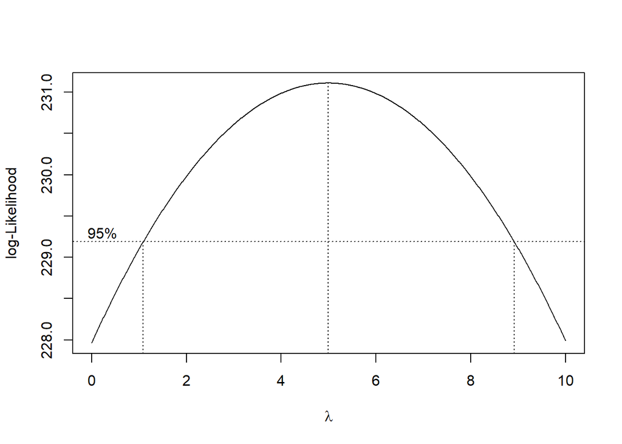

```r
index <- seq(1:292)
bc = boxcox(datatrain.ts~index, lambda = seq(0,10,by=0.01))
```

```r
#Nilai Rounded Lambda
lambda <- bc$x[which.max(bc$y)]
lambda
```

```
## [1] 4.99
```

```r
#SK
bc$x[bc$y > max(bc$y) - 1/2 * qchisq(.95,1)]
```

```
##   [1] 1.09 1.10 1.11 1.12 1.13 1.14 1.15 1.16 1.17 1.18 1.19 1.20 1.21 1.22 1.23
##  [16] 1.24 1.25 1.26 1.27 1.28 1.29 1.30 1.31 1.32 1.33 1.34 1.35 1.36 1.37 1.38
##  [31] 1.39 1.40 1.41 1.42 1.43 1.44 1.45 1.46 1.47 1.48 1.49 1.50 1.51 1.52 1.53
##  [46] 1.54 1.55 1.56 1.57 1.58 1.59 1.60 1.61 1.62 1.63 1.64 1.65 1.66 1.67 1.68
##  [61] 1.69 1.70 1.71 1.72 1.73 1.74 1.75 1.76 1.77 1.78 1.79 1.80 1.81 1.82 1.83
##  [76] 1.84 1.85 1.86 1.87 1.88 1.89 1.90 1.91 1.92 1.93 1.94 1.95 1.96 1.97 1.98
##  [91] 1.99 2.00 2.01 2.02 2.03 2.04 2.05 2.06 2.07 2.08 2.09 2.10 2.11 2.12 2.13
## [106] 2.14 2.15 2.16 2.17 2.18 2.19 2.20 2.21 2.22 2.23 2.24 2.25 2.26 2.27 2.28
## [121] 2.29 2.30 2.31 2.32 2.33 2.34 2.35 2.36 2.37 2.38 2.39 2.40 2.41 2.42 2.43
## [136] 2.44 2.45 2.46 2.47 2.48 2.49 2.50 2.51 2.52 2.53 2.54 2.55 2.56 2.57 2.58
## [151] 2.59 2.60 2.61 2.62 2.63 2.64 2.65 2.66 2.67 2.68 2.69 2.70 2.71 2.72 2.73
## [166] 2.74 2.75 2.76 2.77 2.78 2.79 2.80 2.81 2.82 2.83 2.84 2.85 2.86 2.87 2.88
## [181] 2.89 2.90 2.91 2.92 2.93 2.94 2.95 2.96 2.97 2.98 2.99 3.00 3.01 3.02 3.03
## [196] 3.04 3.05 3.06 3.07 3.08 3.09 3.10 3.11 3.12 3.13 3.14 3.15 3.16 3.17 3.18
## [211] 3.19 3.20 3.21 3.22 3.23 3.24 3.25 3.26 3.27 3.28 3.29 3.30 3.31 3.32 3.33
```

[output cut: 38 more lines]

Gambar di atas menunjukkan nilai *rounded value* ($\lambda$) optimum sebesar **4,99** dan pada selang kepercayaan 95% nilai memiliki batas bawah **1,09** dan batas atas **8,91**. Selang tersebut tidak memuat nilai satu sehingga dapat dikatakan bahwa data bangkitan tidak stasioner dalam ragam.

#Identifikasi model

#Plot ACF PACF

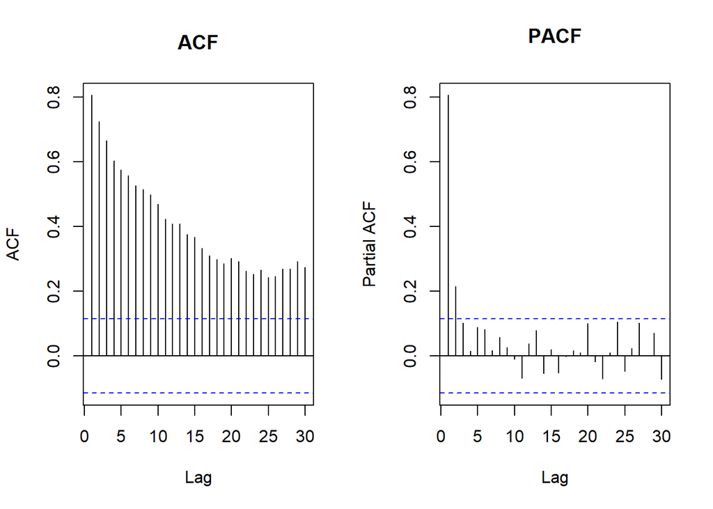

```r
par(mfrow = c(1,2))
acf(datatrain.ts, main="ACF", lag.max=30) #ARIMA(0,0,2)
pacf(datatrain.ts, main="PACF", lag.max=30) #ARIMA(1,0,0)
```

#Plot EACF

```r
eacf(datatrain.ts)
```

```
## AR/MA
##   0 1 2 3 4 5 6 7 8 9 10 11 12 13
## 0 x x x x x x x x x x x  x  x  x
## 1 x o o o o o o o o o o  o  o  o
## 2 x x o o o o o o o o o  o  o  o
## 3 x x o o o o o o o o o  o  o  o
## 4 x x x o o o o o o o o  o  o  o
## 5 x x x x o o o o o o o  o  o  o
## 6 x x x x x o o o o o o  o  o  o
## 7 x x x o x x o o o o o  o  o  o
```

#Penduga parameter

#ARIMA (1,0,0)

```r
### ARIMA (1,0,0)
model1=Arima(datatrain.ts, order=c(1,0,0),method="ML")
summary(model1) #AIC=302.51
```

```
## Series: datatrain.ts
## ARIMA(1,0,0) with non-zero mean
##
## Coefficients:
##          ar1     mean
##       0.8042  24.7206
## s.e.  0.0343   0.1183
##
## sigma^2 = 0.1622:  log likelihood = -148.26
## AIC=302.51   AICc=302.59   BIC=313.54
##
## Training set error measures:
##                        ME      RMSE       MAE        MPE     MAPE      MASE
## Training set -0.001358538 0.4013205 0.3190621 -0.0321714 1.293762 0.9428013
##                    ACF1
## Training set -0.1719831
```

```r
lmtest::coeftest(model1) #signifikan
```

```
##
## z test of coefficients:
##
##            Estimate Std. Error z value  Pr(>|z|)
## ar1        0.804171   0.034307   23.44 < 2.2e-16 ***
## intercept 24.720631   0.118281  209.00 < 2.2e-16 ***
## ---
## Signif. codes:  0 '***' 0.001 '**' 0.01 '*' 0.05 '.' 0.1 ' ' 1
```